# Exam MF9555

Ole Gunnar Tveit

2018-05-14

Excercises are answered using R, version 3.4.4.

## Excercise 1

### Excercise 1a

A substantial amount of data are missing gender and weight. This seems to be placeholder information for mothers with only one or two births, and is actually not births. Should thus be ok to exclude these.

I will first construct a table and boxplot of gender/birth_no:

```r
d1 %>%
  group_by(birth_no, gender) %>%
  summarise(count = n(), mean_weight = mean(weight, na.rm = T)) %>%
  select(birth_no, gender, mean_weight) %>%
  na.omit() %>%
  spread(gender, mean_weight, sep=" ") %>%
  kable(format = 'pandoc', caption="Mean weigth by birth number and gender")
```

Mean weigth by birth number and gender

| birth_no | gender 1 | gender 2 |
| --- | --- | --- |
| 1 | 3367 | 3511 |
| 2 | 3483 | 3593 |
| 3 | 3451 | 3629 |

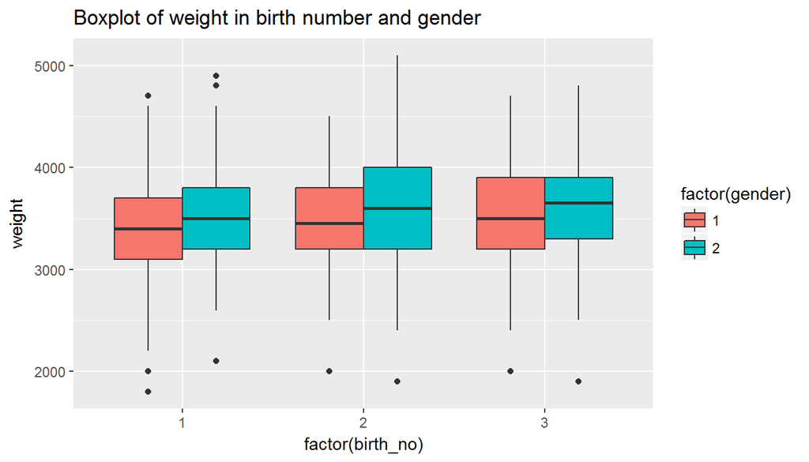

Boxplot of weight by birth number and gender

```r
d1 %>%
  na.omit() %>%
  group_by(birth_no, gender) %>%
  ggplot(aes(x=factor(birth_no), y=weight, fill=factor(gender))) +
  geom_boxplot() +
  ggtitle("Boxplot of weight in birth number and gender")
```

### Excercise 1b

Building a linear regression model with *gender*, *birth_no* and (born) *after1959*:

```r
# generate variable for mother born after 1.1.60
d1$after_1959 <- (d1$birth_mo > 59)*1
# linear model
d1.mod_b <- lm(weight ~ factor(gender) + factor(birth_no) + after_1959, data=d1)


kable(round(cbind(tidy(d1.mod_b)[2:5], confint(d1.mod_b)),3),
  format = 'pandoc', caption="Linear model regression results with the explanatory variables gender, birth order and mother born after 1959")
```

Linear model regression results with the explanatory variables gender, birth order and mother born after 1959

|  | estimate | std.error | statistic | p.value | 2.5 % | 97.5 % |
| --- | --- | --- | --- | --- | --- | --- |
| (Intercept) | 3356.10 | 44.38 | 75.618 | 0.000 | 3268.927 | 3443.3 |
| factor(gender)2 | 137.78 | 43.21 | 3.188 | 0.002 | 52.899 | 222.7 |
| factor(birth_no)2 | 100.51 | 48.03 | 2.093 | 0.037 | 6.168 | 194.8 |
| factor(birth_no)3 | 104.71 | 60.91 | 1.719 | 0.086 | -14.934 | 224.4 |
| after_1959 | 28.41 | 43.41 | 0.654 | 0.513 | -56.854 | 113.7 |

We see a significant difference of genders, estimated to 137.78, 95%CI=[52.89, 222.65] and p=.0015. We would thus expect boys to weigh on average 137.78 grams more than girls. There is also a significant difference between birth_no of 1 and 2 estimated to 100.51, 95%CI=[6.16, 194.84] and p=.037. The difference between birth_no 1 and 3 is estimated to 104.71, 95%CI=[-14.93, 224.35], and is not significant with p=.086. The effect of mothers born before 1.1.1960 was not found significant, with p=.513.

### Excercise 1c

Building the model from 1b with a mixed model approach, with random intercepts for mothers:

```r
# mixed model
d1.mod_c <- lmer(weight ~ factor(gender) + factor(birth_no) + after_1959 + (1 | mother), data=d1)

table_1c <- round(data.frame(coef(summary(d1.mod_c)), CI=round(confint(d1.mod_c)[3:7,], 2)), 3)
colnames(table_1c) <- c("estimate", "std.error", "df", "t-value", "p-value", "2.5%", "97.5%")
kable(table_1c, format = 'pandoc', caption="Linear mixed model regression results with the explanatory variables gender, birth order and mother born after 1959 ")
```

Linear mixed model regression results with the explanatory variables gender, birth order and mother born after 1959

|  | estimate | std.error | df | t-value | p-value | 2.5% | 97.5% |
| --- | --- | --- | --- | --- | --- | --- | --- |
| (Intercept) | 3352.31 | 46.13 | 439.8 | 72.676 | 0.000 | 3262.11 | 3442.5 |
| factor(gender)2 | 139.22 | 38.95 | 478.6 | 3.574 | 0.000 | 63.08 | 215.4 |
| factor(birth_no)2 | 101.78 | 37.83 | 331.5 | 2.690 | 0.007 | 27.73 | 175.8 |
| factor(birth_no)3 | 90.95 | 49.93 | 360.8 | 1.822 | 0.069 | -6.67 | 188.8 |
| after_1959 | 34.47 | 53.57 | 253.6 | 0.644 | 0.520 | -70.37 | 139.4 |

We see a significant difference of genders , estimated to 139.22, 95%CI=[63.07, 215.39] and p<.001. We would thus expect boys to weigh on average 139.22 grams more than girls. There is also a significant difference between birth_no of 1 and 2 estimated to 101.78, 95%CI=[ 27.72, 175.81] and p=.007. The difference between birth_no 1 and 3 is estimated to 90.95, 95%CI=[-6.66, 188.76], and is not significant with p=.069. The effect of mothers born before 1.1.1960 was not found significant, with p=.520.

Adding random intercept of mothers to the model reduces unceirtainty of the model, which we see by the standard errors of the coefficients. The std.error for gender, birth_no2 and birth_no3 is 43.2, 48.0 and 60.9 with the linear model, but is reduced to 38.9, 37.8 and 49.9 with the mixed model. This is related to some of the variance being explained by the random intercepts, and lead to higher test statistics and lower p-values.

### Excercise 1d

We can check the correlation of siblings birth weight by calculating the interclass correlation (ICC). This will give us the variation explained by the clustering unit, IE. mother. We calculate ICC by dividing the variance for the clustering unit (mother variance = 110635) by the total variance (mother variance: 110635 + residual variance: 153980). We then get 0,418. The icc method of the sjstats library in R calculates the ICC of mother to: 0.4181, which confirms our calculation.

In conclusion, birth weight of siblings seems to have a correlation of 0.418.

### Excercise 1e

Correlated birth weight between siblings may be related to genetic components, but there are a number of other reasons that may contribute this correlation. For example: Mothers behaviour during pregnancy like smoking, caffeine intake or exercise may impact birth weight. And mothers behavior during different pregnancies could very well correlate. This could lead to a correlation of siblings birth weight even if disregarding genetic components. Thus we should be careful of making statements about genetic components based on an observed correlation.

## Excercise 2

### Excercise 2a

To describe the data I have made a plot with binomial fit seen in figure 2.

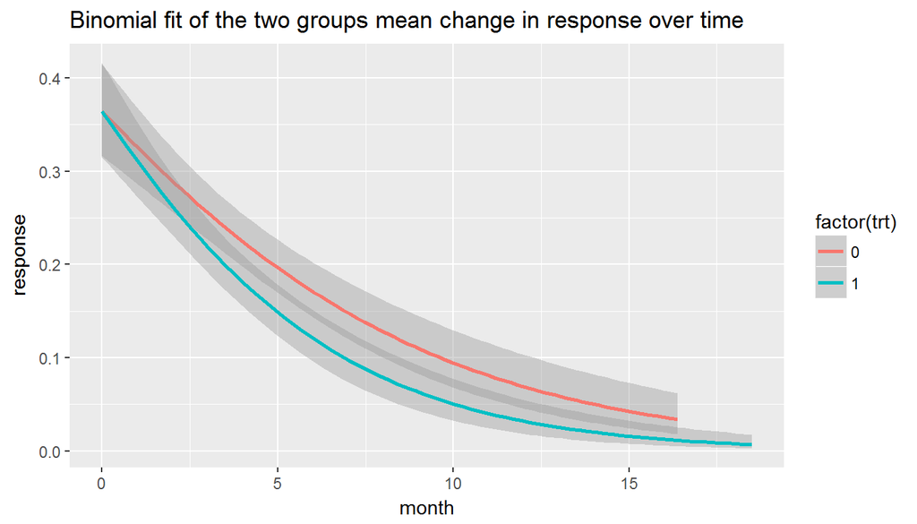

Binomial fit of the two groups mean change in response over time

```r
d2 %>%
  ggplot(aes(x = month, y = response, color = factor(trt))) +
#  geom_count() +
  geom_smooth(aes(), method = "glm", method.args = list(family = "binomial")) +
  ggtitle("Binomial fit of the two groups mean change in response over time")
```

To get numeric sense of difference I have created a table (table 4) showing mean respons in the two groups at different timepoints (I used visit instead of month here, to get an illustration of development that is easier to interpret).

```r
d2 %>%
  group_by(trt, visit) %>%
  summarise(response = mean(response)) %>%
  spread(trt, response, sep=" ") %>%
  data.frame() %>%
  kable(format = 'pandoc', caption="Mean response by visit and treatment group")
```

Mean response by visit and treatment group

| visit | trt.0 | trt.1 |
| --- | --- | --- |
| 1 | 0.3699 | 0.3716 |
| 2 | 0.3475 | 0.3265 |
| 3 | 0.3188 | 0.2759 |
| 4 | 0.2197 | 0.2071 |
| 5 | 0.1077 | 0.0602 |
| 6 | 0.0855 | 0.0630 |
| 7 | 0.1053 | 0.0458 |

Response in this data means patient(s) with moderate or severe separation of nail plate from nail bed. The two groups seem to have an approximately equal response at baseline, with treatment B (trt=1) showing a steeper reduction in moderate/severe symptoms as compared to treatment A. The difference in response is greatest after 7-8 months, but there is still a difference at the last timepoint.

### Excercise 2b

I chose to build a marginal model with GEE, with ‘id’ as the clustering unit. I will compare different working correlations. Models will include *month* + *trt* + *month:trt* as explanatory variables. Table 5 show coefficients and QIC for the models with different working correlations:

```r
# four gee models, with different covariance structures
d2.b_uns <- geeglm(response ~ trt * month , id=id, family=binomial, corstr = "unstructured", data=d2)
d2.b_ar <- geeglm(response ~ trt * month , id=id, family=binomial, corstr = "ar1", data=d2)
d2.b_ind <- geeglm(response ~ trt * month , id=id, family=binomial, corstr = "independence", data=d2)
d2.b_exc <- geeglm(response ~ trt * month , id=id, family=binomial, corstr = "exchangeable", data=d2)

# find QIC, and rank the models:
model.sel(d2.b_uns, d2.b_ar, d2.b_ind, d2.b_exc, rank = QIC) %>%
  select(-df) %>%
  kable(format = 'pandoc', caption="Model comparison of different working correlations")
```

Model comparison of different working correlations

|  | (Intercept) | month | trt | month:trt | corstr | qLik | QIC | delta | weight |
| --- | --- | --- | --- | --- | --- | --- | --- | --- | --- |
| d2.b_uns | -0.7396 | -0.1319 | 0.0373 | -0.0896 | unstructured | -910.6 | 1835 | 0.0000 | 0.4194 |
| d2.b_ar | -0.6441 | -0.1376 | 0.0691 | -0.0968 | ar1 | -909.1 | 1836 | 0.9065 | 0.2666 |
| d2.b_ind | -0.5566 | -0.1703 | -0.0006 | -0.0672 | independence | -908.0 | 1837 | 1.5488 | 0.1934 |
| d2.b_exc | -0.5819 | -0.1713 | 0.0072 | -0.0777 | exchangeable | -908.3 | 1838 | 2.4921 | 0.1206 |

Results from the model using *unstructured*:

```r
# coefficients w/ CI95%
table_2b <- round(cbind(OR=exp(d2.b_uns$coefficients),
                        tidy(d2.b_uns)[2:3],
                        OR=exp(confint(d2.b_uns)),
                        p=tidy(d2.b_uns)[5]), 3)
colnames(table_2b) <- c("OR", "estimate", "std.error", "2.5%", "97.5%", "p-value")
kable(table_2b, format = 'pandoc', caption="GEE results using unstructured working correlation")
```

GEE results using unstructured working correlation

|  | OR | estimate | std.error | 2.5% | 97.5% | p-value |
| --- | --- | --- | --- | --- | --- | --- |
| (Intercept) | 0.477 | -0.740 | 0.166 | 0.344 | 0.661 | 0.000 |
| trt | 1.038 | 0.037 | 0.247 | 0.640 | 1.684 | 0.880 |
| month | 0.876 | -0.132 | 0.026 | 0.832 | 0.923 | 0.000 |
| trt:month | 0.914 | -0.090 | 0.048 | 0.832 | 1.005 | 0.063 |

### Excercise 2c

$\beta_2$ is ln(OR) for the group for one additional month, and is estimated to OR=.876. This equals to a reduction in odds of the groups response by about 12.4% for each additional month. For trt=0 $\beta_2$ captures the mean group change per month. For trt=1 $\beta_2$ is used in addition to $\beta_3$ to capture the change per month. The $\beta_2$ coefficient is significant with p<.001.

$\beta_3$ is the coefficient for the trt*month-interaction. The estimated OR=.914, which could be understood as an additional 8.6% reduced odds of response per month for treatment group B (trt=1).

### Excercise 2d

The interaction-coefficient *trt:month* is not significant at $\alpha$ = 0.05, with p=.063. But as the patients are randomized to different groups (and seem to be equal at baseline from the plot), we can force the baseline difference between groups to be 0, by including only *month* and *trt:month* in the model. This will put all of the difference between groups in the interaction term. Results with this new model is summarized in following table:

```r
d2.modb_uns_random <- geeglm(response ~ month + trt:month, id=id, family=binomial, corstr = "unstructured", data=d2)
# coefficients w/ CI95%
kable(round(data.frame(cbind(OR=exp(d2.modb_uns_random$coefficients),
      tidy(d2.modb_uns_random)[2:3],
      OR=exp(confint(d2.modb_uns_random)),
      p=tidy(d2.modb_uns_random)[5])), 3),
  format = 'pandoc', caption="GEE results after excluding trt as individual factor")
```

GEE results after excluding trt as individual factor

|  | OR | estimate | std.error | OR.2.5 | OR.97.5 | p.value |
| --- | --- | --- | --- | --- | --- | --- |
| (Intercept) | 0.486 | -0.722 | 0.123 | 0.382 | 0.619 | 0.000 |
| month | 0.875 | -0.133 | 0.025 | 0.833 | 0.919 | 0.000 |
| month:trt | 0.917 | -0.086 | 0.042 | 0.844 | 0.997 | 0.042 |

### Excercise 2e

Based on the model in excercise 2b, build a generalized linear mixed model (GLMM) with random intercepts for individuals. Based on results with marginal models I willcompare two models with random intercepts: one model with (mode_1) and one without (mode_2) *trt* as an individual fixed effect.

```r
d2.mode_1 <- glmer(response ~ trt * month + (1 | id), family=binomial, data=d2)
d2.mode_2 <- glmer(response ~ month + trt:month + (1 | id), family=binomial, data=d2)

kable(anova(d2.mode_1, d2.mode_2),
  format = 'pandoc', caption="Comparison of GLMM with and without trt")
```

Comparison of GLMM with and without trt

|  | Df | AIC | BIC | logLik | deviance | Chisq | Chi Df | Pr(>Chisq) |
| --- | --- | --- | --- | --- | --- | --- | --- | --- |
| d2.mode_2 | 4 | 1264 | 1286 | -627.9 | 1256 | NA | NA | NA |
| d2.mode_1 | 5 | 1266 | 1293 | -627.8 | 1256 | 0.1983 | 1 | 0.6561 |

The two models does not appear significantly different from each other based on anova comparison, with p=.66. But based on AIC the model without *trt* gives a better fit (AIC 1264 vs 1266), and I choose to proceed with this model.

Results are shown in table 9. As expected (because we now look at individuals effects instead of group effects), the effects in this mixed model are larger than found in the marginal model.

```r
# coefficients w/ CI95%
table_2e_b <- round(data.frame(cbind(OR=exp(coef(summary(d2.mode_2)))[,1],
                                     coef(summary(d2.mode_2)),
                                     CI=exp(confint(d2.mode_2,parm="beta_",method="Wald")))), 3)
colnames(table_2e_b) <- c("OR", "estimate", "std.error", "z-value", "p-value", "2.5%", "97.5%")
kable(table_2e_b, format = 'pandoc', caption="GLMM results")
```

GLMM results

|  | OR | estimate | std.error | z-value | p-value | 2.5% | 97.5% |
| --- | --- | --- | --- | --- | --- | --- | --- |
| (Intercept) | 0.071 | -2.649 | 0.709 | -3.738 | 0.00 | 0.018 | 0.284 |
| month | 0.673 | -0.396 | 0.046 | -8.663 | 0.00 | 0.616 | 0.736 |
| month:trt | 0.865 | -0.146 | 0.067 | -2.176 | 0.03 | 0.758 | 0.986 |

$\beta_2$ is the coefficient for the fixed effect *month*, giving ln(OR) of response. In this model, $\beta_2$ gives the change per month for an individual in group A (trt=0). The estimated OR is .673, which means a reduction of 32.7% in response.

$\beta_3$ is the coefficient for the *month:trt* interaction, giving ln(OR) of respons. In this model, $\beta_3$ contributes, together with $beta_2$, to the change per month for an individual in group B (trt=1). The change per month for individuals in group B is found by multiplyting $\beta_2$ with $\beta_3$, 0.6733*0.8646 = 0.582. This gives an odds of reduction in response for individuals in group B at 41.8% for an additional month.

### Excercise 2f

For group A (trt=0), the OR after 7 months is 0.673^7 = 0.0625. 7 months of treatment reduce the odds of outcome by 93.7% for individuals in group A. For group B (trt=1), the OR after 7 months is (0.673^7 * 0.865^7) = 0.0227. 7 months of treatment reduce the odds of outcome by 97.7% for individuals in group B.

## Excercise 3

```r
d3.re <- d3 %>%
  gather(key = time, value = response, visit0, visit1, visit2, visit3, visit4, -center, -id, -treat, -gender, -age) %>%
  arrange(id) %>%
  mutate(time = substring(time, 6)) %>%
  mutate(time = as.numeric(time))
```

### Excercise 3a

To check if the effect of time is linear I will plot development over time for groups and for groups at centers:

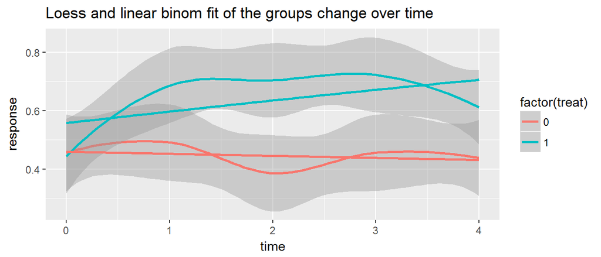

Loess and linear binom fit of the groups change over time

```r
d3.re %>%
  ggplot(aes(x = time, y = response, color = factor(treat))) +
  stat_smooth(method="loess", se=T) +
  geom_smooth(method="glm", method.args = list(family = "binomial"), se=F) +
  ggtitle("Loess and linear binom fit of the groups change over time")
```

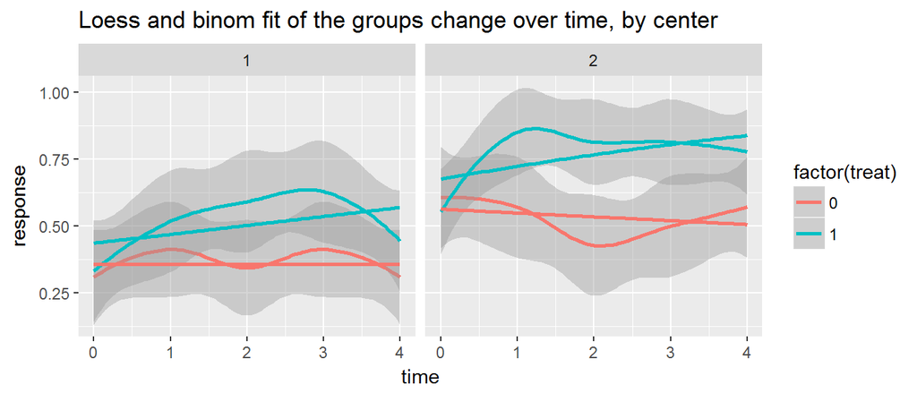

Loess and binom fit of the groups change over time, by center

```r
d3.re %>%
  ggplot(aes(x = time, y = response, color = factor(treat))) +
  stat_smooth(method="loess", se=T) +
  geom_smooth(method="glm", method.args = list(family = "binomial"), se=F) +
  facet_wrap(~center) +
  ggtitle("Loess and binom fit of the groups change over time, by center")
```

Treatment group 1 seem to follow a non-linear development over time, while development in group 0 more closely resembles linearity. A linear fit will overestimate respons in group 1 at timepoints 0 and 4, and underestimate response at timepoint 1 to 3. The change in response in group 1 from increasing in the beginning to decreasing towards the end will be lost with a linear model.

As the loess plot of development in group 1 is looking curvelinear I will try to fit a binomial line with a polynomial input (time + time^2):

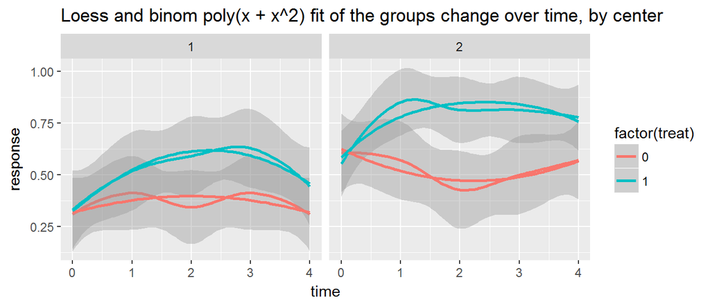

Loess and binom poly(x + x^2) fit of the groups change over time, by center

```r
d3.re %>%
  ggplot(aes(x = time, y = response, color = factor(treat))) +
  stat_smooth(method="loess", se=T) +
  geom_smooth(method="glm", method.args = list(family = "binomial"), formula = y ~ x + I(x^2), se=F) +
  facet_wrap(~center) +
  ggtitle("Loess and binom poly(x + x^2) fit of the groups change over time, by center") #, for the two centers
```

This seem to capture the development in treatment group 1 better than the linear binomial fit (with loess as reference), and also a decent fit for in group 0. For group 0 the polynomial line looks inversed for the two centers. Adding a third order factor did not seem to improve the fit.

In conclusion, it seems unreasonable to assume that the development over time is linear.

### Excercise 3b

Some possible approaches to deal with nonlinear development could be:

**Use meaningful summary statistics**: Possible summary statistics could be looking only at respons at last timepoint, looking at change in response from timepoint 0 to timepoint 4. Then we could test differences with a t-test. There are also other possible summary measures like area-under-curve, time-until-max, and peak value. When using summary statistics you loose information, so it is important to choose an approach that gives good information about what you care about. In our case we might be interested in who has the best response at the and, who got cured, so it might be useful to test the difference in respons between the two groups at timepoint 4.

**Convert variable to categorical**: In some cases it may be useful to analyse the variable as a categorical variable instead of as a continous variable. The the effect may be interpreted as “odds ratio at this point in time compared to a reference point”, where reference point is usually the first timepoint. If the time development seem to have one bend (change in development), it may be fruitful the select the timepoint at the bend as reference. Then you may look at time development before and after this change/bend.

**Transform the independent variables**: Sometime a transformation of the independent variables could make a nonlinear relationship with the dependent variable into a linear relationship. Common transformations are log(x), sqrt(x) or 1/x. Something to think about is how to interpret the results, what does the transformed variable mean? For the task at hand i think it makes more sense to try to:

**Model the nonlinearity with polynomials**: A variation of the above is building a model that takes into account the nonlinearity trough polynomials. This acts kind of like an interaction, with for instance the variable time interacting with itself when you include *time^2* as a fixed effect. This approach was used in the plots above, where i included *time* and *time^2* to get a fit more similar to the loess fit. As the development over time seemed different in the tow treatment groups (more curvelinear in group 1), i will also try to include *time^2* as en interaction with *treat*

### Excercise 3c

I will build a model using a mixed model approach, starting with random intercepts for id. I will try to include the non-linear elements with polynomials. I will build towards a model wich includes the fixed effects: time, treat:time, time^2, treat:time^2 and center. But will also build less complex models to compare fit by AIC, and check which fixed effects should be included.

Comparison of some of the models tested is shown in table 10. Model 1 (center + age + time + treat:time), model 2 (model 1 + time^2) and model 3 (model 2 + treat:time^2).

```r
d3.m_c1 <- glmer(response ~ center + age + time + treat:time + (1 | id), family=binomial , data=d3.re)
d3.m_c2 <- glmer(response ~ center + age + time + treat:time + I(time^2) + (1 | id), family=binomial , data=d3.re)
d3.m_c3 <- glmer(response ~ center + age + time + treat:time + I(time^2) + I(treat*time^2) + (1 | id), family=binomial , data=d3.re)

model.sel(d3.m_c1, d3.m_c2, d3.m_c3, rank=AIC) %>%
  kable(format = 'pandoc', caption="Comparison of GLMM by AIC",
        col.names = c("(Int)", "age", "cnt", "tim", "tim:trt", "tim^2", "trt:tim^2", "df", "logLik", "AIC", "delta", "weight"), align = "c")
```

Comparison of GLMM by AIC

|  | (Int) | age | cnt | tim | tim:trt | tim^2 | trt:tim^2 | df | logLik | AIC | delta | weight |
| --- | --- | --- | --- | --- | --- | --- | --- | --- | --- | --- | --- | --- |
| d3.m_c3 | -2.061 | -0.0342 | 1.907 | -0.1824 | 2.1029 | 0.0338 | -0.442 | 8 | -290.2 | 596.5 | 0.000 | 0.988149 |
| d3.m_c2 | -1.919 | -0.0342 | 1.827 | 0.5556 | 0.4583 | -0.1667 | NA | 7 | -295.8 | 605.6 | 9.167 | 0.010098 |
| d3.m_c1 | -1.568 | -0.0337 | 1.796 | -0.1076 | 0.4582 | NA | NA | 6 | -298.6 | 609.1 | 12.669 | 0.001753 |

Some additional notes on model building:

```r
tidy(d3.m_c3)[1:7,1:5] %>%
  mutate(OR = exp(estimate), #var.diag = diag(vcov(d3.mod_c3)),
         var.diag = diag(vcov(d3.m_c3)),
         OR.se = sqrt(OR^2 * var.diag),
         OR.ci25 = exp(estimate - 1.96 * std.error),
         OR.ci975 = exp(estimate + 1.96 * std.error)) %>%
  select(term, OR, OR.se, OR.ci25, OR.ci975, statistic, p.value) %>%
  mutate_if(is.numeric, round, digits=3) %>%
  kable(format = 'pandoc', caption="GLMM results final model",
        col.names = c("term", "OR", "std.error", "2.5%", "97.5%", "z-value", "p-value"))
```

GLMM results final model

| term | OR | std.error | 2.5% | 97.5% | z-value | p-value |
| --- | --- | --- | --- | --- | --- | --- |
| (Intercept) | 0.127 | 0.123 | 0.019 | 0.847 | -2.132 | 0.033 |
| center | 6.732 | 3.675 | 2.309 | 19.625 | 3.493 | 0.000 |
| age | 0.966 | 0.019 | 0.930 | 1.005 | -1.732 | 0.083 |
| time | 0.833 | 0.316 | 0.396 | 1.752 | -0.481 | 0.631 |
| I(time^2) | 1.034 | 0.097 | 0.860 | 1.243 | 0.360 | 0.719 |
| I(treat * time^2) | 0.643 | 0.088 | 0.492 | 0.839 | -3.245 | 0.001 |
| time:treat | 8.190 | 4.384 | 2.868 | 23.386 | 3.928 | 0.000 |

My final model, with a summary shown in Table 11, includes the explanatory variables *age*, *center*, *time*, *treat:time*, *time^2*, _treat*time^2_ as fixed effects and have random intercepts for id’s.

There seems to a significant difference between the two treatments, as the terms capturing effect of treatment group (the interaction terms *treat:time*, and *treat:time^2*) is significant. *time:treat* is significant with p<.001 and *treat:time^2* is significant with p=.001. The odds ratio of *treat* is calculated by the following: $OR(treat) = 0.643^{t^2} * 8.190^t$, where t = time. This give the following OR for *treat* at the different timepoints:

```r
or_time_table <- data.frame(timepoint=0, formula="0.643^0 * 8.190^0", OR=1, stringsAsFactors = F)
for (t in 1:4) {
  time = t
  formula = sprintf("0.643^%d * 8.190^%d", t^2, t)
  or = 0.643^(t^2) * 8.190^t
  ans = c(time, formula, round(or, 2))
  or_time_table <- rbind(or_time_table, ans)
}
kable(or_time_table, format = 'pandoc', caption="OR for treat at different timepoints")
```

OR for treat at different timepoints

| timepoint | formula | OR |
| --- | --- | --- |
| 0 | 0.643^0 * 8.190^0 | 1 |
| 1 | 0.643^1 * 8.190^1 | 5.27 |
| 2 | 0.643^4 * 8.190^2 | 11.47 |
| 3 | 0.643^9 * 8.190^3 | 10.32 |
| 4 | 0.643^16 * 8.190^4 | 3.84 |

In conclusion, there is a significant time effect of treatment (treat = 1, vs treat = 0). The effect of being in the treatment group is stronger at timepoint 2 and 3 than at timepoint 1 and 4

### Excercise 3d

In a scientific paper i would present: the model and method of analysis, the terms with or, variation and p-value in table and graphics; and the random effects with ICC.

```r
tidy(d3.m_c3)[1:7,1:5] %>%
  mutate(Coefficient = term,
         OR = exp(estimate), #var.diag = diag(vcov(d3.mod_c3)),
         var.diag = diag(vcov(d3.m_c3)),
         or.se = sqrt(or^2 * var.diag),
         or.ci25 = exp(estimate - 1.96 * std.error),
         or.ci975 = exp(estimate + 1.96 * std.error),
         CI.95 = sprintf("[ %.2f, %.2f]", or.ci25, or.ci975)) %>%
  select(Coefficient, OR, CI.95, p.value) %>%
  mutate_if(is.numeric, round, digits=3) %>%
  kable(format = 'pandoc', caption="Fixed effects estimated with GLMM",
        col.names = c("Coefficient", "OR", "95% CI", "p-value"))
```

Fixed effects estimated with GLMM

| Coefficient | OR | 95% CI | p-value |
| --- | --- | --- | --- |
| (Intercept) | 0.127 | [ 0.02, 0.85] | 0.033 |
| center | 6.732 | [ 2.31, 19.63] | 0.000 |
| age | 0.966 | [ 0.93, 1.00] | 0.083 |
| time | 0.833 | [ 0.40, 1.75] | 0.631 |
| I(time^2) | 1.034 | [ 0.86, 1.24] | 0.719 |
| I(treat * time^2) | 0.643 | [ 0.49, 0.84] | 0.001 |
| time:treat | 8.190 | [ 2.87, 23.39] | 0.000 |

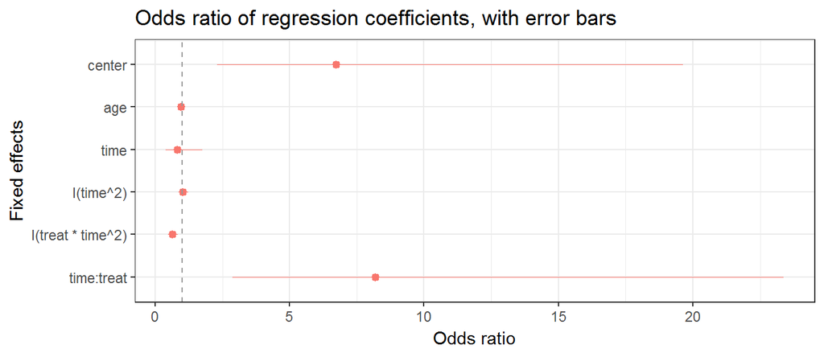

Dot plot with error bars of OR of regression coefficients, vertical line at OR=1

```r
# https://cran.r-project.org/web/packages/dotwhisker/vignettes/kl2007_examples.html
tidy(d3.m_c3)[1:7,1:5] %>%
  mutate(or = exp(estimate), #var.diag = diag(vcov(d3.mod_c3)),
         var.diag = diag(vcov(d3.m_c3)),
         conf.low = exp(estimate - 1.96 * std.error),
         conf.high = exp(estimate + 1.96 * std.error),
         std.error = sqrt(or^2 * var.diag),
         estimate = or) %>%
  select(term, estimate, std.error, conf.low, conf.high) %>%
  dwplot +
  theme_bw() +
  theme(legend.position = "none") +
  ggtitle("Odds ratio of regression coefficients, with error bars") +
  xlab("Odds ratio") +
  ylab("Fixed effects") +
  geom_vline(xintercept = 1, colour = "grey60", linetype = 2)
```

This exam answer with code included is avaliable at: https://ogtveit.github.io/exam_mf9555.html